# Machine learning supersymmetry

**Objective**: Build an ML model to predict supersymmetric signals.

We will use the SUSY dataset available from the [UCI Machine Learning Repository](https://archive.ics.uci.edu/ml/datasets.html).

From the [dataset](https://archive.ics.uci.edu/ml/datasets/SUSY#) description:

> The first column is the class label (1 for signal, 0 for background), followed by the 18 features (8 low-level features then 10 high-level features): lepton 1 pT, lepton 1 eta, lepton 1 phi, lepton 2 pT, lepton 2 eta, lepton 2 phi, missing energy magnitude, missing energy phi, MET_rel, axial MET, M_R, M_TR_2, R, MT2, S_R, M_Delta_R, dPhi_r_b, cos(theta_r1). For detailed information about each feature see the original paper.

**References:**

- Baldi, P., P. Sadowski, and D. Whiteson “Searching for Exotic Particles in High-energy Physics with Deep Learning.” [Nature Communications 5 (July 2, 2014)](https://www.nature.com/articles/ncomms5308)

## General module imports

```python
import numpy as np
from sklearn.model_selection import train_test_split
from sklearn.model_selection import GridSearchCV
from sklearn.linear_model import SGDClassifier
import  sklearn.metrics as metrics
from sklearn.metrics import precision_recall_curve
from sklearn.metrics import roc_curve
from sklearn.metrics import roc_auc_score
from sklearn.model_selection import learning_curve
from sklearn.svm import SVC
from sklearn.svm import LinearSVC
from sklearn.model_selection import cross_val_score
import pandas as pd
import os

os.environ['KMP_DUPLICATE_LIB_OK']='True'
import xgboost as xgb
from xgboost import XGBClassifier


%matplotlib inline
import matplotlib
import matplotlib.pyplot as plt
plt.rcParams['axes.labelsize'] = 14
plt.rcParams['xtick.labelsize'] = 12
plt.rcParams['ytick.labelsize'] = 12
plt.style.use('ggplot')

import warnings
warnings.filterwarnings('ignore')
```

## Get the data

We import the data. However, we'll import only 10k samples. My tests reveal that this is enough to get good performance and results. Using more than this is computationally quite expensive for what I want to do here.

Since we are using only a small subset of all the data (out of a total of 5e6 datapoints) we expect our performance to be a conservative bound on what can be achieved with the full dataset.

Data set is quite clean and balanced, so we focus on the model building.

```python
filename=os.path.join(os.getcwd(), "SUSY.csv")

columns=["signal", "lepton 1 pT", "lepton 1 eta", "lepton 1 phi", "lepton 2 pT", "lepton 2 eta",
         "lepton 2 phi", "missing energy magnitude", "missing energy phi", "MET_rel",
         "axial MET", "M_R", "M_TR_2", "R", "MT2", "S_R", "M_Delta_R", "dPhi_r_b", "cos(theta_r1)"]

N_tot=1e4
df_susy=pd.read_csv(filename,names=columns,nrows=N_tot,engine='python')
```

```python
df_susy.isna().values.any() #alias for isnull()
```

```
False
```

```python
print('\n ** info:')
print()
print(df_susy.info())
```

```
 ** info:

<class 'pandas.core.frame.DataFrame'>
RangeIndex: 10000 entries, 0 to 9999
Data columns (total 19 columns):
signal                      10000 non-null float64
lepton 1 pT                 10000 non-null float64
lepton 1 eta                10000 non-null float64
lepton 1 phi                10000 non-null float64
lepton 2 pT                 10000 non-null float64
lepton 2 eta                10000 non-null float64
lepton 2 phi                10000 non-null float64
missing energy magnitude    10000 non-null float64
missing energy phi          10000 non-null float64
MET_rel                     10000 non-null float64
axial MET                   10000 non-null float64
M_R                         10000 non-null float64
M_TR_2                      10000 non-null float64
R                           10000 non-null float64
MT2                         10000 non-null float64
S_R                         10000 non-null float64
M_Delta_R                   10000 non-null float64
dPhi_r_b                    10000 non-null float64
cos(theta_r1)               10000 non-null float64
dtypes: float64(19)
memory usage: 1.4 MB
None
```

```python
df_susy.describe()
```

|  | signal | lepton 1 pT | lepton 1 eta | lepton 1 phi | lepton 2 pT | lepton 2 eta | lepton 2 phi | missing energy magnitude | missing energy phi | MET_rel | axial MET | M_R | M_TR_2 | R | MT2 | S_R | M_Delta_R | dPhi_r_b | cos(theta_r1) |
| --- | --- | --- | --- | --- | --- | --- | --- | --- | --- | --- | --- | --- | --- | --- | --- | --- | --- | --- | --- |
| count | 10000.000000 | 10000.000000 | 10000.000000 | 10000.000000 | 10000.000000 | 10000.000000 | 10000.000000 | 10000.000000 | 10000.000000 | 10000.000000 | 10000.000000 | 10000.000000 | 10000.000000 | 10000.000000 | 10000.000000 | 10000.000000 | 10000.000000 | 10000.000000 | 1.000000e+04 |
| mean | 0.458000 | 0.998473 | -0.004496 | -0.000648 | 0.993125 | -0.010946 | 0.015393 | 1.008317 | -0.000015 | 0.995831 | 0.005236 | 0.999703 | 0.999350 | 0.999739 | 0.998307 | 0.998105 | 1.003046 | 0.997132 | 2.268696e-01 |
| std | 0.498258 | 0.678865 | 1.002655 | 1.004128 | 0.641595 | 1.004209 | 0.999310 | 0.918953 | 1.001747 | 0.893580 | 1.044459 | 0.633916 | 0.585771 | 0.473709 | 0.846912 | 0.627091 | 0.623232 | 0.437639 | 1.992722e-01 |
| min | 0.000000 | 0.265829 | -2.102170 | -1.734093 | 0.428693 | -2.058400 | -1.733843 | 0.002086 | -1.727112 | 0.000276 | -7.638416 | 0.281638 | 0.015300 | 0.024300 | 0.000000 | 0.155334 | 0.007738 | 0.000697 | 3.520310e-07 |
| 25% | 0.000000 | 0.562303 | -0.760981 | -0.871676 | 0.592593 | -0.772137 | -0.856581 | 0.482739 | -0.864014 | 0.372441 | -0.487227 | 0.591083 | 0.621670 | 0.649112 | 0.186255 | 0.597679 | 0.519666 | 0.686590 | 6.736385e-02 |
| 50% | 0.000000 | 0.794279 | -0.001058 | 0.001626 | 0.799632 | -0.002408 | 0.022697 | 0.770998 | -0.011874 | 0.785423 | -0.083003 | 0.831152 | 0.875933 | 0.932084 | 0.903385 | 0.837265 | 0.917411 | 1.090262 | 1.704890e-01 |
| 75% | 1.000000 | 1.207049 | 0.754134 | 0.876795 | 1.161719 | 0.759213 | 0.878354 | 1.197405 | 0.870776 | 1.370520 | 0.336507 | 1.206306 | 1.212240 | 1.282868 | 1.603113 | 1.199121 | 1.386425 | 1.369750 | 3.329400e-01 |
| max | 1.000000 | 8.843125 | 2.101403 | 1.734187 | 9.153182 | 2.059194 | 1.734349 | 13.680408 | 1.740314 | 11.626125 | 13.375183 | 13.969072 | 6.523737 | 5.335464 | 4.195099 | 14.024200 | 5.267689 | 1.591609 | 9.533260e-01 |

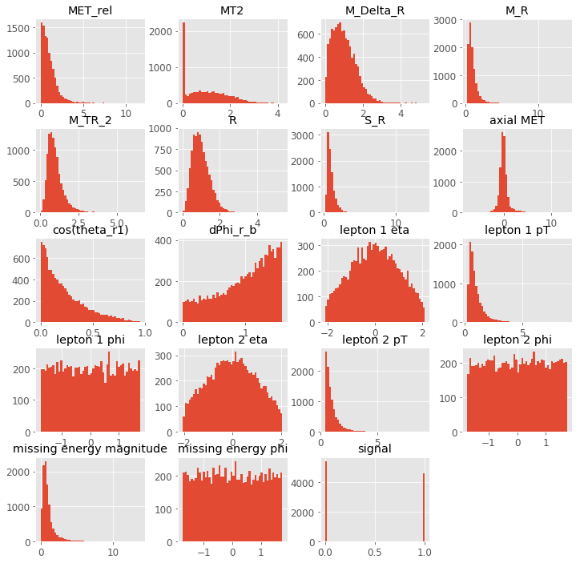

```python
df_susy.hist(bins=50,figsize=(12,12))#bins default=10
plt.show()
```

```python
df_susy.corr()
```

|  | signal | lepton 1 pT | lepton 1 eta | lepton 1 phi | lepton 2 pT | lepton 2 eta | lepton 2 phi | missing energy magnitude | missing energy phi | MET_rel | axial MET | M_R | M_TR_2 | R | MT2 | S_R | M_Delta_R | dPhi_r_b | cos(theta_r1) |
| --- | --- | --- | --- | --- | --- | --- | --- | --- | --- | --- | --- | --- | --- | --- | --- | --- | --- | --- | --- |
| signal | 1.000000 | 0.395465 | -0.008555 | -0.009855 | 0.198736 | -0.003698 | 0.002461 | 0.427744 | 0.020575 | 0.280748 | 0.078727 | 0.266896 | 0.424222 | 0.111094 | 0.079901 | 0.256233 | 0.281247 | 0.025986 | 0.268620 |
| lepton 1 pT | 0.395465 | 1.000000 | -0.006154 | -0.002011 | 0.676000 | 0.014061 | 0.005623 | 0.385004 | -0.005188 | 0.173673 | -0.004188 | 0.842152 | 0.724957 | -0.180290 | -0.012881 | 0.800373 | 0.248558 | -0.141628 | 0.165692 |
| lepton 1 eta | -0.008555 | -0.006154 | 1.000000 | 0.001755 | -0.012209 | 0.399006 | -0.009899 | -0.004400 | -0.004856 | -0.003827 | 0.004705 | -0.019853 | -0.010428 | -0.004553 | -0.014520 | -0.019707 | -0.019918 | 0.001301 | -0.001634 |
| lepton 1 phi | -0.009855 | -0.002011 | 0.001755 | 1.000000 | 0.009910 | 0.001168 | -0.266166 | -0.011580 | -0.182535 | -0.005978 | -0.002260 | 0.006337 | 0.000833 | -0.007192 | 0.011715 | 0.007246 | 0.007514 | -0.005668 | -0.007382 |
| lepton 2 pT | 0.198736 | 0.676000 | -0.012209 | 0.009910 | 1.000000 | 0.010457 | -0.013429 | 0.150486 | -0.006622 | 0.009358 | 0.086621 | 0.789484 | 0.432237 | -0.321718 | -0.123954 | 0.790609 | 0.024827 | 0.007603 | -0.220525 |
| lepton 2 eta | -0.003698 | 0.014061 | 0.399006 | 0.001168 | 0.010457 | 1.000000 | -0.003349 | 0.003905 | -0.013744 | 0.014492 | -0.005813 | 0.019315 | 0.012883 | -0.000536 | 0.010989 | 0.018138 | 0.012646 | 0.003472 | -0.004951 |
| lepton 2 phi | 0.002461 | 0.005623 | -0.009899 | -0.266166 | -0.013429 | -0.003349 | 1.000000 | 0.005758 | -0.033351 | 0.000297 | 0.001883 | -0.000619 | 0.002708 | 0.004907 | 0.001942 | -0.003147 | 0.003227 | -0.001862 | 0.010872 |
| missing energy magnitude | 0.427744 | 0.385004 | -0.004400 | -0.011580 | 0.150486 | 0.003905 | 0.005758 | 1.000000 | 0.013435 | 0.704869 | 0.222313 | 0.269826 | 0.709257 | 0.435265 | 0.187159 | 0.313226 | 0.583212 | 0.375018 | 0.410134 |
| missing energy phi | 0.020575 | -0.005188 | -0.004856 | -0.182535 | -0.006622 | -0.013744 | -0.033351 | 0.013435 | 1.000000 | -0.000033 | 0.004158 | -0.008037 | 0.006451 | 0.011596 | 0.000003 | -0.006732 | 0.005107 | 0.010460 | 0.020907 |
| MET_rel | 0.280748 | 0.173673 | -0.003827 | -0.005978 | 0.009358 | 0.014492 | 0.000297 | 0.704869 | -0.000033 | 1.000000 | -0.110746 | 0.090345 | 0.586375 | 0.585030 | 0.521504 | 0.161688 | 0.739441 | 0.382852 | 0.311604 |
| axial MET | 0.078727 | -0.004188 | 0.004705 | -0.002260 | 0.086621 | -0.005813 | 0.001883 | 0.222313 | 0.004158 | -0.110746 | 1.000000 | 0.035472 | -0.294761 | -0.381575 | -0.527830 | -0.057935 | -0.337674 | -0.061723 | -0.258532 |
| M_R | 0.266896 | 0.842152 | -0.019853 | 0.006337 | 0.789484 | 0.019315 | -0.000619 | 0.269826 | -0.008037 | 0.090345 | 0.035472 | 1.000000 | 0.574355 | -0.375090 | -0.063089 | 0.980670 | 0.206153 | -0.080057 | -0.117009 |
| M_TR_2 | 0.424222 | 0.724957 | -0.010428 | 0.000833 | 0.432237 | 0.012883 | 0.002708 | 0.709257 | 0.006451 | 0.586375 | -0.294761 | 0.574355 | 1.000000 | 0.380739 | 0.374751 | 0.634966 | 0.674836 | 0.244223 | 0.446788 |
| R | 0.111094 | -0.180290 | -0.004553 | -0.007192 | -0.321718 | -0.000536 | 0.004907 | 0.435265 | 0.011596 | 0.585030 | -0.381575 | -0.375090 | 0.380739 | 1.000000 | 0.578064 | -0.276093 | 0.554871 | 0.414855 | 0.623513 |
| MT2 | 0.079901 | -0.012881 | -0.014520 | 0.011715 | -0.123954 | 0.010989 | 0.001942 | 0.187159 | 0.000003 | 0.521504 | -0.527830 | -0.063089 | 0.374751 | 0.578064 | 1.000000 | -0.015943 | 0.795349 | 0.052328 | 0.262008 |
| S_R | 0.256233 | 0.800373 | -0.019707 | 0.007246 | 0.790609 | 0.018138 | -0.003147 | 0.313226 | -0.006732 | 0.161688 | -0.057935 | 0.980670 | 0.634966 | -0.276093 | -0.015943 | 1.000000 | 0.264610 | 0.016098 | -0.086499 |
| M_Delta_R | 0.281247 | 0.248558 | -0.019918 | 0.007514 | 0.024827 | 0.012646 | 0.003227 | 0.583212 | 0.005107 | 0.739441 | -0.337674 | 0.206153 | 0.674836 | 0.554871 | 0.795349 | 0.264610 | 1.000000 | 0.157874 | 0.315258 |
| dPhi_r_b | 0.025986 | -0.141628 | 0.001301 | -0.005668 | 0.007603 | 0.003472 | -0.001862 | 0.375018 | 0.010460 | 0.382852 | -0.061723 | -0.080057 | 0.244223 | 0.414855 | 0.052328 | 0.016098 | 0.157874 | 1.000000 | 0.104592 |
| cos(theta_r1) | 0.268620 | 0.165692 | -0.001634 | -0.007382 | -0.220525 | -0.004951 | 0.010872 | 0.410134 | 0.020907 | 0.311604 | -0.258532 | -0.117009 | 0.446788 | 0.623513 | 0.262008 | -0.086499 | 0.315258 | 0.104592 | 1.000000 |

```python
#the dataset is quite balanced:
df_susy.signal.value_counts()
```

```
0.0    5420
1.0    4580
Name: signal, dtype: int64
```

```python
#Random splitting with sklearn:
train_set, test_set = train_test_split(df_susy, test_size=0.2, random_state=99)

X_train, y_train =train_set.iloc[:,1:], train_set.iloc[:,:1]
X_test, y_test   =test_set.iloc[:,1:], test_set.iloc[:,:1]
```

```python
train_set.shape
```

```
(8000, 19)
```

## Useful Routines

First, I code some routines that will be useful for the rest.

These will be written in a project-independent way so that I can reuse them elsewhere.

```python
def get_probab_and_score(model,X=X_train,y=y_train,T=X_test):
    """Calculates and returns probablities and scores of a given classifier. """
    model.fit(X,y)
    score=model.score(X,y)
    probabilities = model.predict_proba(T)
    return (probabilities,score)


def plot_PrecisionRecall_vs_threshold(model,X=X_train,y=y_train, yT=y_test):
    fig, ax = plt.subplots()
    probabilities,_=get_probab_and_score(model,X,y)
    precision, recall, thresholds = precision_recall_curve(yT, probabilities[:, 1])
    pr_auc = metrics.auc(recall, precision)
    plt.title("Precision and Recall vs Threshold")
    plt.plot(thresholds, precision[: -1], "b--", label="Precision")
    plt.plot(thresholds, recall[: -1], "r--", label="Recall")
    plt.ylabel("Precision, Recall")
    plt.xlabel("Threshold of identification")
    plt.legend(loc="lower left")
    plt.ylim([0,1])
    plt.show()
    return

def plot_ROC(model,X=X_train,y=y_train, yT=y_test):
    probabilities,_=get_probab_and_score(model,X,y)
    fpr, tpr, thresholds = roc_curve(yT,probabilities[:, 1])
    auc=roc_auc_score(yT, probabilities[:, 1])
    fig, ax = plt.subplots()
    plt.title(f'ROC curve (area={auc:.2f})')
    plt.xlabel('False Positive Rate')
    plt.ylabel('True Positive Rate')
    plt.plot([0, 1], [0, 1], linestyle='--')
    plt.plot(fpr, tpr, marker='.')
    plt.show()
    return


def plot_Learningcurve(model,X=X_train,y=y_train,scoring='roc_auc'):
    train_sizes, train_scores, test_scores = learning_curve(model, X, y, cv=5, scoring=scoring,train_sizes=np.linspace(.05, 1.0, 10))
    train_scores_mean = np.mean(train_scores, axis=1)
    train_scores_std = np.std(train_scores, axis=1)
    test_scores_mean = np.mean(test_scores, axis=1)
    test_scores_std = np.std(test_scores, axis=1)

    fig, ax = plt.subplots()
    plt.fill_between(train_sizes, train_scores_mean - train_scores_std,
                         train_scores_mean + train_scores_std, alpha=0.1,
                         color="r")
    plt.fill_between(train_sizes, test_scores_mean - test_scores_std,
                         test_scores_mean + test_scores_std, alpha=0.1, color="g")
    plt.plot(train_sizes, train_scores_mean, 'o-', color="r",
                 label="Training score")
    plt.plot(train_sizes, test_scores_mean, 'o-', color="g",
                 label="Cross-validation score")

    plt.xlabel("Training examples")
    plt.ylabel("Score")
    plt.legend(loc="best")
    plt.legend(loc="lower right")
    plt.grid("on")
    plt.show()
    return



def NKfolding_finetuning(model,X=X_train,y=y_train,scoring='roc_auc',N=10,k=5,**ParamsToTune):
    """Makes N times K-fold cross validation on the training set and returns the mean
    of the tuned parameters, and the mean of the score and its std deviation."""
    params=[]
    scores=[]
    for i in range(N):
        clf = GridSearchCV(model,ParamsToTune,cv=k,scoring=scoring)
        clf.fit(X,y)
        params.append(clf.best_params_)
        scores.append([clf.best_score_,clf.cv_results_["std_test_score"][clf.best_index_]])
    pdparams=pd.DataFrame(params)
    best_score=np.mean(scores,axis=0)
    return (dict(pdparams.mean()),best_score[0],best_score[1])

def simple_finetuning(model,X=X_train,y=y_train,scoring='roc_auc',**ParamsToTune):
    """Implements a 5-folded gridSearch on a given classifier.
    Returns (BestFitParams, BestScore, STD deviation from BestScore)"""
    clf = GridSearchCV(model,ParamsToTune,cv=5,scoring=scoring)
    clf.fit(X,y)
    return  (clf.best_params_,clf.best_score_,clf.cv_results_["std_test_score"][clf.best_index_])

def NKfolding(model,X=X_train,y=y_train,N=10,k=5,scoring='roc_auc'):
    """Makes N times K-fold cross validation on the data and returns the mean
    of the score and its std deviation."""
    scores=[]
    for i in range(N):
        scores.append(np.mean(cross_val_score(model, X, y, cv=k,scoring=scoring)))
    return (np.mean(scores))
```

## Find the best classifier

The procedure is as follows:

- Split the data into training+test sets(80:20).
- Define a list of classifiers and their parameters. We'll use:
  - Logistic regression (SGD-optimized)
  - "Logistic regression" with $L_1$ loss function
  - Linear SVC from the LinearSVC module
  - SVM with RBF kernel
  - XGboost
- For each estimator, do 10 x 5-fold cross-validations on the training set to tune their hyper-parameters.
- Compare the tuned models using the AUC score (most relevant for our case of signal discrimination).
- Finally, calculate the predictions of the 'winning' tuned model and calculate its score using the full data set following the same procedure as above for consistency. (It is OK to use the full data in this way since we are not using it tune the model.)

```python
classifiers=[SGDClassifier,LinearSVC,SVC, XGBClassifier]

params_SGD=[]
params_SGD.append({'loss':"log", 'penalty':"l1",'alpha':1e-6,'max_iter':10})
params_SGD.append({'loss':"log", 'penalty':"l2",'alpha':1e-6,'max_iter':10})

params_LinSVC=[]
params_LinSVC.append({'C':1.0,'penalty':"l2"})

params_SVC=[]
params_SVC.append({'C':1.0,'gamma':'auto','kernel':'rbf', 'probability':True})


params_XG=[]
params_XG.append({'max_depth': 6, 'min_child_weight': 3,'gamma': 0,'learning_rate': 0.01})


params=[params_SGD,params_LinSVC,params_SVC,params_XG]
```

[output not shown]

[figure not shown]

[output not shown]

[figure not shown]

[output not shown]

[figure not shown]

[output not shown]

[figure not shown]

[output not shown]

[figure not shown]

```python
#Pre-tuning learning curves

for classifier,args in zip(classifiers,params):
    for param in args:
        print(classifier)
        print(param)
        plot_Learningcurve(classifier(**param))
```

```python
#search grids for the tuning per class of estimator.

params_grid_SGD= {'alpha': 10.0**-np.arange(0,6,0.5) }
params_grid_LinSVM= {'C': 10.0**-np.arange(-2,2,1) }
params_grid_SVM= {'C': 10.0**-np.arange(-2,2,1) }
params_grid_XG={'C': 10.0**-np.arange(-2,2,1), 'min_child_weight': [1,3,5], 'learning_rate':[0.01,0.1,0.3]}


params_grid=[params_grid_SGD,params_grid_LinSVM,params_grid_SVM,params_grid_XG]
```

```python
#Find best model.

best_score_prior=0
for classifier,args,grid in zip(classifiers,params,params_grid):
    for param in args:
        print('Tuning for model:')
        print(classifier)
        print('with parameters:')
        print(param)
        best_params,best_score,best_score_var=NKfolding_finetuning(classifier(**param),X=X_train,y=y_train,N=10,k=5,scoring='roc_auc',**grid)
        print(f'Best fit parameters = {best_params}')
        print(f'Best score = {best_score:.3f} +/- {best_score_var:.3f}.')
        print('-----')
        if(best_score>=best_score_prior):
            new_params=dict(param)
            new_params.update(best_params)
            best_model=classifier(**new_params)
            best_score_prior=best_score
```

```
Tuning for model:
<class 'sklearn.linear_model.stochastic_gradient.SGDClassifier'>
with parameters:
{'loss': 'log', 'penalty': 'l1', 'alpha': 1e-06, 'max_iter': 10}
Best fit parameters = {'alpha': 0.0015119288512538815}
Best score = 0.854 +/- 0.009.
-----
Tuning for model:
<class 'sklearn.linear_model.stochastic_gradient.SGDClassifier'>
with parameters:
{'loss': 'log', 'penalty': 'l2', 'alpha': 1e-06, 'max_iter': 10}
Best fit parameters = {'alpha': 0.00208113883008419}
Best score = 0.852 +/- 0.009.
-----
Tuning for model:
<class 'sklearn.svm.classes.LinearSVC'>
with parameters:
{'C': 1.0, 'penalty': 'l2'}
Best fit parameters = {'C': 3.6100000000000003}
Best score = 0.855 +/- 0.009.
-----
Tuning for model:
<class 'sklearn.svm.classes.SVC'>
with parameters:
{'C': 1.0, 'gamma': 'auto', 'kernel': 'rbf', 'probability': True}
Best fit parameters = {'C': 1.0}
Best score = 0.864 +/- 0.010.
-----
Tuning for model:
<class 'xgboost.sklearn.XGBClassifier'>
with parameters:
{'max_depth': 6, 'min_child_weight': 3, 'gamma': 0, 'learning_rate': 0.01}
Best fit parameters = {'C': 100.0, 'learning_rate': 0.09999999999999999, 'min_child_weight': 5.0}
Best score = 0.858 +/- 0.008.
-----
```

## Final assessment

We have quantified the performance of our models, tuned their parameters, and estimated their uncertainties. It appears that the procedure of doing 10 times 5-folds cross-validation gives good results. This is the procedure we will adapt for finalizing the model. We can now use the full dataset with one of the models. However, it apperas that Non-linear SVM classification with RBF kernel works best for our task together with the XGboost algorithm although the latter is also much slower than the former.

We will use XGboost to derive some explainable results, as the plot of the feature importance. After which we plot the final learning curve, and ROC ('Signal efficiency' vs. 'Background Rejection in our case).

```python
best_model
```

```
SVC(C=1.0, cache_size=200, class_weight=None, coef0=0.0,
  decision_function_shape='ovr', degree=3, gamma='auto', kernel='rbf',
  max_iter=-1, probability=True, random_state=None, shrinking=True,
  tol=0.001, verbose=False)
```

```python
nextbest_model=XGBClassifier(**{'C': 1000.0,'max_depth': 6, 'min_child_weight': 5, 'gamma': 0, 'learning_rate': 0.01})
```

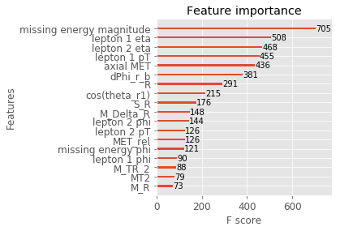

```python
nextbest_model.fit(X_train,y_train)
fig=plt.figure()
xgb.plot_importance(nextbest_model, ax=plt.gca())
fig.subplots_adjust(left=0.4)
```

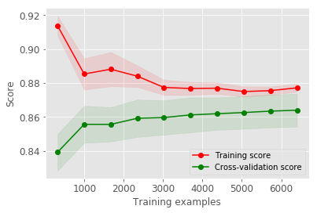

```python
plot_Learningcurve(best_model)
```

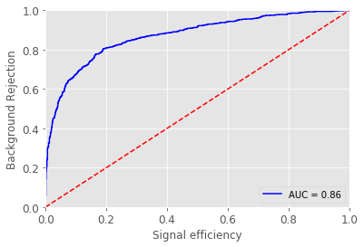

```python
best_model.fit(X_train,y_train)
probabilities = best_model.predict_proba(X_test)
fig, ax = plt.subplots()
fpr, tpr, _ = roc_curve(y_test, probabilities[:,1])

plt.plot(fpr, tpr, 'b', label = 'AUC = %0.2f' % 0.864)
plt.legend(loc = 'lower right')
plt.plot([0, 1], [0, 1],'r--')
plt.xlim([0, 1])
plt.ylim([0, 1])
plt.xlabel('Signal efficiency')
plt.ylabel('Background Rejection')
plt.show()
```

```python
fulldata_set, _ = train_test_split(df_susy, test_size=0.)

X_full, y_full =fulldata_set.iloc[:,1:], fulldata_set.iloc[:,:1]
```

```python
best_score=NKfolding(best_model,X=X_full,y=y_full,N=10,k=5,scoring='roc_auc')
print(f'{best_score:.2f}')
```

```
0.87
```